# Assignment 8

Thomas Walsh

2023-01-26

###Question1 Go through your recent assignments and the posted solutions (Assignment 6 posted solutions and Weekly Assignment 2 solutions) - compare your code to the posted code. Can you run your simulated data function with new values for the means? If not, what do you need to change about your code? Are there differences between the posted code and yours? Did you notice you were missing anything? Make sure you annotate your code using # and leave brief descriptions of your thought process.

My code for Assignment 6 is also identical to the answer key. I did not use the %in% operator for question 2 which would have made the process more efficient. Additionally, in the last question, I did not arrange by descending average sepal length which would have been better for piping.

For Weekly Assignment 2, my code was far less efficient, my code looked like:

myFunc <- function(meanControl=NULL, meanTreatment=NULL)#### I needed to define the two means sds and n value as arguments here{ Type <- c(rep(“Control”, 25), rep(“Treatment”, 25)) ## I should have used each here to be more efficient Value <- c(rnorm(25, mean=10, sd=1.5), rnorm(25, mean=45, sd=2)) dF <- data.frame(Type, Value, stringsAsFactors = FALSE) meanControl <- mean(Value[1:25]) meanTreatment <- mean(Value[26:50]) ## I did not need these two lines and should have specified them in the arguments and in the Value return(dF) }

My ANOVA portion was also very unefficient, I should have created a function just to return a pvalue without any data. My function looked like:

myFunc2 <- function(meanControl2=NULL, meanTreatment2=NULL){ Type2 <- c(rep(“Control2”, 25), rep(“Treatment2”, 25)) Value2 <- c(rnorm(25, mean=10, sd=1.5), rnorm(25, mean=45, sd=2)) dF2 <- data.frame(Type2, Value2, stringsAsFactors = FALSE) meanControl2 <- mean(Value2[1:25]) meanTreatment2 <- mean(Value2[26:50]) ### I didn’t need any of the above stuff. sum<-summary(aov(dF2$Value2~dF2$Type2, data=dF2)) final<-sum[[1]][[“Pr(>F)”]][1] return(final)

```r
set.seed(123)
simData <- function(mean1=10, sd1=1.5, mean2=45, sd2=2, n=25){

  Type <- rep(c("Control", "Treatment"), each = n)
  Value <- c(rnorm(n, mean = mean1, sd = sd1), rnorm(n, mean = mean2, sd = sd2))
  dframe <- data.frame(Type, Value)
  return(dframe)
}

data<-simData()

head(data)
```

```
##      Type     Value
## 1 Control  9.159287
## 2 Control  9.654734
## 3 Control 12.338062
## 4 Control 10.105763
## 5 Control 10.193932
## 6 Control 12.572597
```

```r
myPval <- function(df=NULL){

  test <- aov(Value ~ Type, data=df)
  testSummary <- summary(test)
  p_value <- testSummary[[1]][["Pr(>F)"]][1]
  return(p_value)
}

myPval(df=data)
```

```
## [1] 1.183614e-51
```

```r
myPval(simData())
```

```
## [1] 7.541268e-53
```

```r
##################################################
# This is my edited code
myFunc <- function(meanC=10, sdC=1.5, meanT = 45, sdT=2, n=25){
Type <- c(rep("Control", n), rep("Treatment", n))
Value <- c(rnorm(n, mean=meanC, sd=sdC), rnorm(n, mean=meanT, sd=sdT))
dF <- data.frame(Type, Value, stringsAsFactors = FALSE)
return(dF)
}

dataFrame <- myFunc()
head(dataFrame)
```

```
##      Type     Value
## 1 Control  8.934390
## 2 Control 10.385326
## 3 Control  9.629962
## 4 Control  9.478686
## 5 Control  8.572572
## 6 Control  9.932458
```

```r
summary(aov(dataFrame$Value~dataFrame$Type, data=dataFrame))
```

```
##                Df Sum Sq Mean Sq F value Pr(>F)
## dataFrame$Type  1  15272   15272    4412 <2e-16 ***
## Residuals      48    166       3
## ---
## Signif. codes:  0 '***' 0.001 '**' 0.01 '*' 0.05 '.' 0.1 ' ' 1
```

```r
 myFunc2 <- function(df=NULL){
sum<-summary(aov(Value~Type, data=df))
final<-sum[[1]][["Pr(>F)"]][1]
return(final)
}
 myFunc2(df=dataFrame)
```

```
## [1] 6.714387e-49
```

```r
 myFunc2(myFunc())
```

```
## [1] 1.002742e-51
```

```r
 #### This is my edited code to make my work more efficient and reproducible.
```

Question 2

```r
## Set up libraries
library(tidyverse)
library(ggthemes)


# Data obtained from Veysey Powell and Babbitt 2016: An experimental test of buffer utility as a technique for managing pool-breeding amphibians https://datadryad.org/stash/dataset/doi:10.5061%2Fdryad.547rp

dryadData<- read.table(file="veysey-babbitt_data_amphibians.csv", header =TRUE, sep=",")
getwd()
```

```
## [1] "C:/Users/twals/OneDrive/Desktop/BIOL1007A/Assignments"
```

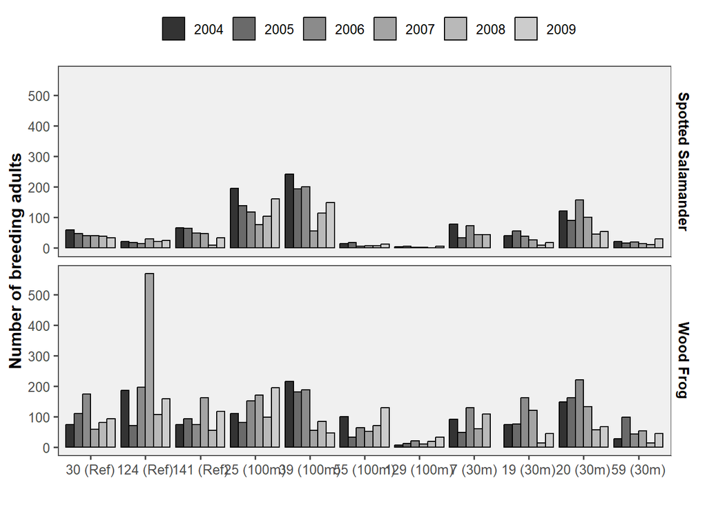

```r
# glimpse(dryadData)
# head(dryadData)
# table(dryadData$species)

dryadData$species<-factor(dryadData$species, labels=c("Spotted Salamander", "Wood Frog")) #creating 'labels' to use for the plot

#class(dryadData$treatment)
dryadData$treatment <- factor(dryadData$treatment,
            levels=c("Reference",
                     "100m", "30m"))
 ## factors data into correct places, ref 100 and 30 m


p<- ggplot(data=dryadData, #specifies data
       aes(x=interaction(wetland, treatment),# group wetland and treatment
           y=count.total.adults, fill=factor(year))) + geom_bar(position="dodge",stat="identity", color="black") + # creates bar graph with total count as y,  with legend, sets orientation of bars correctly,
  ylab("Number of breeding adults") + # labels y axis
  xlab("") +
  scale_y_continuous(breaks = c(0,100,200,300,400,500)) +#sets values for split y axis
  scale_x_discrete(labels=c("30 (Ref)", "124 (Ref)", "141 (Ref)", "25 (100m)","39 (100m)","55 (100m)","129 (100m)", "7 (30m)","19 (30m)","20 (30m)","59 (30m)")) + # sets x axis value labels
  facet_wrap(~species, nrow=2, strip.position="right") +# splits the y axis, without there are not two portion to y axis
  theme_few() + scale_fill_grey() + #sets theme and color of graph
   theme(panel.background = element_rect(fill = 'gray94', color = 'black'), legend.position="top",  legend.title= element_blank(), axis.title.y = element_text(size=12, face="bold", colour = "black"), strip.text.y = element_text(size = 10, face="bold", colour = "black")) +# further edits theme and color of background text, bolding text, text size, legend position above the graph
  guides(fill=guide_legend(nrow=1,byrow=TRUE))# makes legend one row not 2

p
```